# Python_Workshop_Day_1

## Introduction to Python

Python is a general-purpose interpreted, interactive, **object-oriented**, and **high-level programming language**. It was created by Guido van Rossum during 1985- 1990.

Following are important characteristics of Python Programming −

- It supports functional and structured programming methods as well as OOP.
- It can be used as a scripting language or can be compiled to byte-code for building large applications.
- It provides very high-level dynamic data types and supports dynamic type checking.
- It supports automatic garbage collection.
- It can be easily integrated with C, C++ and Java.

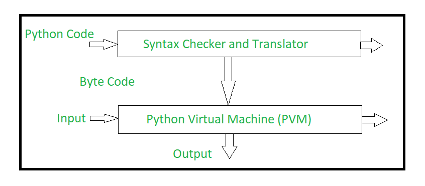

```python
import this
```

```
The Zen of Python, by Tim Peters

Beautiful is better than ugly.
Explicit is better than implicit.
Simple is better than complex.
Complex is better than complicated.
Flat is better than nested.
Sparse is better than dense.
Readability counts.
Special cases aren't special enough to break the rules.
Although practicality beats purity.
Errors should never pass silently.
Unless explicitly silenced.
In the face of ambiguity, refuse the temptation to guess.
There should be one-- and preferably only one --obvious way to do it.
Although that way may not be obvious at first unless you're Dutch.
Now is better than never.
Although never is often better than *right* now.
If the implementation is hard to explain, it's a bad idea.
If the implementation is easy to explain, it may be a good idea.
Namespaces are one honking great idea -- let's do more of those!
```

The Zen of Python is a collection of 19 "guiding principles" for writing computer programs that influence the design of the Python programming language. Software engineer Tim Peters wrote this set of principles and posted it on the Python mailing list in 1999.

## Applications of Python

**Python Applications**

- Web Development
- Game Development
- Machine Learning and Artificial Intelligence
- Data Science and Data Visualization
- Desktop GUI
- Web Scraping Applications
- Business Applications
- Audio and Video Applications
- CAD Applications
- Embedded Applications

```python
## print hello world using python
## Demonstration of print function
print("Hello World!!!")
```

```
Hello World!!!
```

## Python Basics (Data Types, Variables, Typecasting, Dynamic Typing)

Basic Data Types available in Python : (a) Numeric (b) Boolean (c) Sequence (d) Dictionary (e) Sets

(a) Numeric : int $\to$ integers , float $\to$ floating point numbers , complex $\to$ Complex numbers of the form $a+bj$ , $a,b$ $\in \mathbb{R}$

```python
#Some examples: Note that type() function is used to check/ verify the data type

a = 22
print(a , type(a))

b = 22.22
print(b , type(b))

c = 3+4j
print(c , type(c))
```

```
22 <class 'int'>
22.22 <class 'float'>
(3+4j) <class 'complex'>
```

Boolean Values are noting but TRUE/FALSE values. Anything of the type 0 or 1 , ON or OFF , EMPTY or NON-EMPTY, all correspond to Boolean Data Types. Boolean values fall under the Python Class **bool** .

```python
#Some Examples

print(bool(0))
print(bool(1))
print(bool(2)) #Ask participants to determine the Value of bool(3)

print('\n')

print(bool(''), ': This corresponds to an empty string') #Empty String
print(bool(' '), ': This corresponds to a string with a space only.') #String with a space
print(bool('AnyString'), ': This corresponds to any string.')

print('\n')
```

```
False
True
True


False : This corresponds to an empty string
True : This corresponds to a string with a space only.
True : This corresponds to any string.
```

```python
# Easy swapping of values
a = 22
b = 11

print(a,b)

#swap
a,b = b,a

print(a,b)
```

```
22 11
11 22
```

Basic Sequences in Python are: **Lists, Strings, Tuples**

# Lists

(1) Empty Lists are initialized using [] or list()  
(2) The indexation in Lists start from 0 and the last element is of index n-1, where length of list is n.  
(3) The len() function gives length of any sequence/iterable in python.  
(4) The append method of the class list can be used to add elements to the list  
(5) The extend methond extends a list by what is provided as an argument to the function  
(6) The lists are mutable, which can be altered after creation.  
(7) The lists also have negative indexation, where $-1$ corresponds to the last element, whereas $-n$ corresponds to the first element.

```python
l = [] #Empty List
l1 = [1 , 2 , 3 , 4]

print(l)
print(l1)
```

```
[]
[1, 2, 3, 4]
```

```python
#index of a list
l1 = [1,2,3,4]
print(l1[0])
```

```
1
```

```python
l = [1,4,3,2,2,1,3,2] # A random List
#Use of len() function

len(l)
```

```
8
```

```python
l = [1,4,3,2,2,1,3,2]
#l = [-8,-7,-6,-5,-4,-3,-2,-1]
 # A random List
#This List has 8 elements.#len - 1 - len
print(l[-1] , ',which is the last element') #Use of negative indexation
print(l[-8] , ',which is the first element')
```

```
2 ,which is the last element
1 ,which is the first element
```

```python
## Appending to a list

l = [2,4,8,4]
l.append(6) #This inserts 6 at the last position.

print(l)
```

```
[2, 4, 8, 4, 6]
```

```python
## Inserting in a list an element at index i using the insert function
l = [2,4,8,4]

l.insert(2 , 7) # 2 is the argument referring to the index, whereas 7 is the element to be inserted. Don't Worry!! We will circle back to function, its parameters
                # and arguments pretty soon.

print(f'{l}, where you can see that 7 has been inserted at index 2, or the third position.')
```

```
[2, 4, 7, 8, 4], where you can see that 7 has been inserted at index 2, or the third position.
```

```python
## Extending a list and difference between extend and append.

l = [2,4,8,4]
l.append([7,8])
print(l)

l = [2,4,8,4]
l.extend([7,8])
print(l)

print('When you given an argument inside the append method of the list class, it gets added to the list as is. However, extend method extends the list by adding the provided elements in the list. ')
```

```
[2, 4, 8, 4, [7, 8]]
[2, 4, 8, 4, 7, 8]
When you given an argument inside the append method of the list class, it gets added to the list as is. However, extend method extends the list by adding the provided elements in the list.
```

```python
# Lists can be changed after creation.

l = [2,4,8,4]
# Say you want to change the element at index 1 to 5. All you have to do is
l[1] = 5

print(f'{l}, where element at index 1, i.e. 4, is replaced by 5.')
```

```
[2, 5, 8, 4], where element at index 1, i.e. 4, is replaced by 5.
```

```python
# Elements of a list can be removed using the remove method. The remove method removes the first occurence of an element. It raises an error if element is not present
l = [1,2,3,2,4,5,1,2]

l.remove(2)
print(l)

l.remove(1)
print(l)
```

```
[1, 3, 2, 4, 5, 1, 2]
[3, 2, 4, 5, 1, 2]
```

# List Slicing

In Python lists can be sliced according to need to solve problems efficiently. It is achieved using the slicing operator(:)

**Syntax:** List[ Initial : End : Index jump ]

```python
# Displaying data between two indexes
l = [2,5,6,3,1,7,9]
#ne = [-7,-6,-5,-4,-3,-2,-1,0]
print(l[1:5]) # Displays all the values between l[1](included) and l[5](excluded)
print(l[-5:-1]) # Using -ve indexes
print(l[:]) # Displays whole list
```

```
[5, 6, 3, 1]
[6, 3, 1, 7]
[2, 5, 6, 3, 1, 7, 9]
```

```python
# Displaying values at a fixed interval
l = [14,3,5,9,11,2,8,1,12,15,6,4,7]

print(l[::2]) # Displays all values at an interval of 2
print(l[2:-1:3]) # Displays all values at an interval of 3 between l[2](included) and l[-1](excluded)
```

```
[14, 5, 11, 8, 12, 6, 7]
[5, 2, 12, 4]
```

```python
# Reverse a list using -ve Index jump
print(l[::-1])

# With -ve Index jump, indexes in reverse order should be used
print(l[2:-1:-3])  # Empty list as indexes are in wrong order with -ve Index jump
print(l[-2:1:-3])
```

```
[7, 4, 6, 15, 12, 1, 8, 2, 11, 9, 5, 3, 14]
[]
[4, 12, 2, 5]
```

# Strings

Some features of Strings in Python are:  
(1) Strings are immutable sequences in Python, i.e. they cannot be modified once they are created. By modification, I mean that like lists, elements cannot be changed in between like lists.  
(2) Strings are indexable in Python and follows same indexation rule as lists.  
(3) The length of a string can be determined using the len() function.  
(4) The String Class of Python has many inbuilt functions, which will be demonstrated below.  
(5) Empty string can be initialised using '' or "" (quotes with nothing in between them)

```python
string1 = 'Python is FUN'

print(string1)
```

```
Python is FUN
```

```python
## The len() function gives the length of the string

len(string1)
```

```
13
```

```python
# The isupper() method returns True if all characters are uppercase, False otherwise

string2 = 'PYTHON IS FUN'
string2.isupper()
```

```
True
```

```python
# The islower() method returns True if all characters are lowercase, False otherwise

string3 = 'python is fun'
string3.islower()
```

```
True
```

```python
print(string1.isupper())
print(string1.islower())
## Note that in either case, it's printed False
```

```
False
False
```

```python
## The isalpha() method returns True if all characters are alphabetical, i.e. A-Za-z
## The isalnum() method returns True if all characters are alphanumeric, i.e. A-Za-z1-9

string4 = 'This is a Python3 Tutorial'
string5 = 'This is a Python3 Tutorial.'

print(f'string4 = {string4}')
print('string4.isalpha() returns', string4.isalpha())
print('string4.isalnum() returns', string4.isalnum())
```

```
string4 = This is a Python3 Tutorial
string4.isalpha() returns False
string4.isalnum() returns False
```

This happens because there is space character between the words. Let's see what happens if we remove them.

```python
string4 = 'ThisisaPython3Tutorial'
print(f'string4 = {string4}')
print('string4.isalpha() returns', string4.isalpha())
print('string4.isalnum() returns', string4.isalnum())
## .,#@*&^%''"" etc. all are considered to be neither in alphabetical nor in alphanumerical set of characters.
```

```
string4 = ThisisaPython3Tutorial
string4.isalpha() returns False
string4.isalnum() returns True
```

```python
## isnumeric() method returns True if all characters of a string are numeric, False otherwise.

string5 = '123456'
string6 = 'a1b2c3'

print(string5.isnumeric())
print(string6.isnumeric())
```

```
True
False
```

```python
## upper() method converts all characters to uppercase
## lower() method converts all characters to lowercase
## capitalize method converts first character to uppercase and all the rest are converted to lowercase

string7 = 'Python is FUN'

print(string7.upper())
print(string7.lower())
print(string7.capitalize())
```

```
PYTHON IS FUN
python is fun
Python is fun
```

```python
## Strings are indexable

string8 = 'PYTHON'

print(string8[1])
print(string8[-1])
```

```
Y
N
```

```python
## List slicing on Strings

string9 = 'Python is fun'

# Substring
print(string9[:8])

# Reverse
print(string9[::-1])
```

```
Python i
nuf si nohtyP
```

# Tuples

(1) Tuples are also immutable sequences in Python. They cannot be modified after creation.  
(2) An empty tuple can be initialised using () (round parentheses)  
(3) The len() function gives the length of the Tuple.  
(4) Tuples are also indexable and elements can be accessed using square brackets.

```python
t1 = (1,2,3,4)

print(t1, type(t1))
```

```
(1, 2, 3, 4) <class 'tuple'>
```

```python
t1[2]
```

```
3
```

# Sets

The Set Data Structure is very similar to what you study in maths. Every element appears only once in a set.  
(1) Empty set can be created using set()  
(2) A set can contain any number and type of elements, but it cannot have any mutable elements as its member.  
(3) Sets are not indexable in Python.  
(4) The set class have various methods such as add(), discard(), union(), intersection(), issubset(), issuperset(), isdisjoint(), remove(), symmetric_difference()  
(5) Sets can also be created using {}, but during such an initialisation, there must be elements inside it.

```python
s1 = {1,3,2,4,5,6,8,10,'a'}
```

```python
print(s1)
```

```
{1, 2, 3, 4, 5, 6, 8, 10, 'a'}
```

```python
s1.discard(3)
```

```python
print(s1)
```

```
{1, 2, 4, 5, 6, 8, 10, 'a'}
```

For any two sets $A$ and $B$,  
$A \cup B$ can be obtained by A.union(B) or A|B  
$A \cap B$ can be obtained by A.intersection(B) or A&B  
$A \Delta B = (A-B) \cup (B-A)$ can be obtained by A.symmetric_difference(B) or (A-B)|(B-A)  
Whether $A \subseteq B$ can be checked using A.issubset(B)  
Whether $A \supseteq B$ can be checked using A.issuperset(B)  
Whether $A \cap B = \phi$ can be checked using A.isdisjoint(B)

```python
A = {1,3,5,7}
B = {2,4,6,8}
```

```python
A&B
```

```
set()
```

```python
A|B
```

```
{1, 2, 3, 4, 5, 6, 7, 8}
```

```python
A = {1,2,3,5,6}
B = {1,3,2,4,6,8,5}
```

```python
A|B
```

```
{1, 2, 3, 4, 5, 6, 8}
```

```python
A&B
```

```
{1, 2, 3, 5, 6}
```

```python
A.issubset(B)
```

```
True
```

```python
B.issuperset(A)
```

```
True
```

```python
(A-B)|(B-A)
```

```
{4, 8}
```

```python
A = {1,3,5,7}
B = {2,4,6,8}
```

```python
A.isdisjoint(B)
```

```
True
```

```python
A = {1,2,3,5,6}
B = {1,3,2,4,6,8,5}
```

```python
A.isdisjoint(B)
```

```
False
```

# Dictionary

(1) Dictionaries are mutable data structures in Python.  
(2) The elements of a dictionary are **key:value** pairs.  
(3) The values corresponding to a particular key can be accessed using the key.  
(4) There can be multiple values which are same, but the keys of a dictionary have to be unique.  
(5) Some methods of the dictionary class are get(), keys(), values(), items(), update(),

```python
d = {'banana':6 , 'mango':5 , 'apple':5}
```

```python
d['banana']
```

```
6
```

```python
d.get('guava',0) #The first argument is the key you want to retrieve, the second one is the value to be returned if the key is not found.
                  #If key is found, it returns the corresponding value.
```

```
0
```

```python
d.get('banana',0)
```

```
6
```

```python
d.keys()
```

```
dict_keys(['banana', 'mango', 'apple'])
```

```python
list(d.keys())
```

```
['banana', 'mango', 'apple']
```

```python
list(d.values())
```

```
[6, 5, 5]
```

```python
list(d.items())
```

```
[('banana', 6), ('mango', 5), ('apple', 5)]
```

```python
d.update({'jackfruit':9})
```

```python
print(d)
```

```
{'banana': 6, 'mango': 5, 'apple': 5, 'jackfruit': 9}
```

```python
#To delete a key, do the following:

del d['apple']
```

```python
print(d)
```

```
{'banana': 6, 'mango': 5, 'jackfruit': 9}
```

```python
# Iterating over dictionary Keys:

d = {'apples':6 , 'guava':5 , 'orange':5, 'cherry':6, 'mango':5, 'strawberry':10, 'watermelon':10}

for i in d:
  print(i , d[i])
```

```
apples 6
guava 5
orange 5
cherry 6
mango 5
strawberry 10
watermelon 10
```

## Lists - Advanced

```python
#Using individual values from a list and composing an f-string
bicycles = ['trek','cannondale','redline','specialized']
message = f"My first bicycle was a {bicycles[0].title()}."

print(message)
```

```
My first bicycle was a Trek.
```

```python
#del statement works with index
motorcycles = ['honda','yamaha','suzuki']
print(motorcycles)

del motorcycles[1]
print(motorcycles)

#pop function in lists - use the item as you remove it
popped_motorcycle = motorcycles.pop()
print(motorcycles)
print(popped_motorcycle)

#pop from any index
first = motorcycles.pop(0)
print(motorcycles)
print(first)
```

```
['honda', 'yamaha', 'suzuki']
['honda', 'suzuki']
['honda']
suzuki
[]
honda
```

```python
#sort method
cars = ['bmw','audi','toyota','subaru']
cars.sort()#sorting alphabetically
print(cars)
print('\n')

cars.sort(reverse=True)
print(cars)
print('\n')

#sorted method - preserves the original order in the list
print(cars)
print(sorted(cars))
print(cars)
```

```
['audi', 'bmw', 'subaru', 'toyota']


['toyota', 'subaru', 'bmw', 'audi']


['toyota', 'subaru', 'bmw', 'audi']
['audi', 'bmw', 'subaru', 'toyota']
['toyota', 'subaru', 'bmw', 'audi']
```

```python
#reverse method
cars = ['bmw','audi','toyota','subaru']
print(cars)
cars.reverse()
print(cars)
```

```
['bmw', 'audi', 'toyota', 'subaru']
['subaru', 'toyota', 'audi', 'bmw']
```

```python
#appending lists dynamically
numbers = []#declaring an empty list
numbers1 = []
numbers2 = []
numbers3 = []

for i in range(0,10,1):
  numbers.append(i)
  numbers1.append([i,i+1])
  numbers2.extend([i])
  numbers3.insert(i,i)

print(numbers)
print(numbers1)
print(numbers2)
print(numbers3)
```

```
[0, 1, 2, 3, 4, 5, 6, 7, 8, 9]
[[0, 1], [1, 2], [2, 3], [3, 4], [4, 5], [5, 6], [6, 7], [7, 8], [8, 9], [9, 10]]
[0, 1, 2, 3, 4, 5, 6, 7, 8, 9]
[0, 1, 2, 3, 4, 5, 6, 7, 8, 9]
```

## Loop structures in Python

### For loop

The for loop is a finite loop. It is mostly used when the number of iterations required are known beforehand.

```python
### Body of a for loop
''' for i in iterable:
      --do something--'''
print('')
```

```python
#looping through lists
fruits = ["apple", "banana", "cherry"]
for x in fruits:
  print(x)
```

```
apple
banana
cherry
```

```python
#looping through strings
for x in "banana":
  print(x)
```

```
b
a
n
a
n
a
```

```python
#using the break statement
fruits = ["apple", "banana", "cherry"]
for x in fruits:
  print(x)#print statement earlier
  if x == "banana":
    break

print("\n")

fruits = ["apple", "banana", "cherry"]
for x in fruits:
  if x == "banana":
    break
  print(x)#print statement kept later
```

```
apple
banana


apple
```

```python
#using the continue statement
fruits = ["apple", "banana", "cherry"]
for x in fruits:
  if x == "banana":
    continue    #do not print banana
  print(x)
```

```
apple
cherry
```

The range(start=0, stop, step = 1) function, by default starts a sequence from $0$ and returns a sequence upto $n-1$, with a default spacing of $1$.

```python
#range function
for i in range(10):
  print(i, end=' ')
```

```
0 1 2 3 4 5 6 7 8 9
```

```python
#printing even numbers from 0 to 20

for i in range(0 , 21 , 2):        ## Here, I used 21 as the stop point is never included in the sequence returned by the range function.
  print(i, end=' ')
```

```
0 2 4 6 8 10 12 14 16 18 20
```

```python
#else in for loop
for x in range(6):
  print(x)
else:
  print("Finally finished!")
```

```
0
1
2
3
4
5
Finally finished!
```

```python
#The else block will NOT be executed if the loop is stopped by a break statement.
for x in range(6):
  if x == 3: break
  print(x)
else:
  print("Finally finished!")
```

```
0
1
2
```

```python
#nested loop structure
adj = ["red", "big", "tasty"]
fruits = ["apple", "banana", "cherry"]

for x in adj:
  for y in fruits:
    print(x, y)
```

```
red apple
red banana
red cherry
big apple
big banana
big cherry
tasty apple
tasty banana
tasty cherry
```

```python
# Range is looking a little abstract, isn't it ? Here's something to make it a bit more real.

list(range(10))
```

```
[0, 1, 2, 3, 4, 5, 6, 7, 8, 9]
```

```python
tuple(range(10))
```

```
(0, 1, 2, 3, 4, 5, 6, 7, 8, 9)
```

```python
set(range(10))
```

```
{0, 1, 2, 3, 4, 5, 6, 7, 8, 9}
```

```python
#for loop with no content and intent
for x in [0, 1, 2]:
  pass
```

```python
# Iterate through lists simultaneously using zip function
odd = list(range(1,10,2)) # First 5 odd nos.
even = list(range(0,10,2)) # First 5 even nos.

for i,j in zip(odd,even):
  print(i,j, sep=',')   # sep adds a seperator between values printed
```

```
1,0
3,2
5,4
7,6
9,8
```

```python
list(zip(odd, even))
```

```
[(1, 0), (3, 2), (5, 4), (7, 6), (9, 8)]
```

```python
# The loop runs till the length of the shortest list
l1 = ['a','b','c','d']
l2 = [1,2,3]
l3 = list('PYTHON')

for i,j,k in zip(l1,l2,l3):
  print(i,j,k)
```

```
a 1 P
b 2 Y
c 3 T
```

### While loop

The while loop is an indefinite loop. It is preferred over for loop when the number of iterations required is not known beforehand.We work with the while loop by testing a condition and repeat the loop body until the condition is false.

```python
## Body of a while loop

'''while condition==True:
    --do something--'''
print('')
```

```python
i = 1
while i < 6:
  print(i)
  i = i + 1
```

```
1
2
3
4
5
```

```python
#break in while
i = 1
while i < 6:
  print(i)
  if i == 3:
    break
  i += 1
```

```
1
2
3
```

```python
#continue in while
i = 0
while i < 6:
  i += 1
  if i == 3:
    continue
  print(i)
```

```
1
2
4
5
6
```

```python
#else in while - it informs after the loop is fully implemented
i = 1
while i < 6:
  print(i)
  i += 1
else:
  print("i is no longer less than 6")
```

```
1
2
3
4
5
i is no longer less than 6
```

## Input in Python

The input() statement:  
(1) The input() statement is used to read information(input) from the user.  
(2) Anything provided through the input statement will be read as a string. Further manipulations require the input to be converted to a suitable data type.  
(3) The prompt of an input statement can be supplied while using the input statement.

```python
s = input('Enter your Name: ')
print(f'The name entered is {s}')
```

```
Enter your Name: Subhajit Saha
The name entered is Subhajit Saha
```

```python
#Suppose you want to read an int/float value from the user.
r = float(input('Enter the radius of a circle: '))
print(f'The radius of the circle is {r} and its area is {(22/7)*(r**2)} sq. units')
#Similar procedure can be followed for float/bool etc.
```

```
Enter the radius of a circle: 5
The radius of the circle is 5.0 and its area is 78.57142857142857 sq. units
```

# Functions in Python

(1) Functions in Python are defined using the def() keyword.  
(2) A function may or may not always return something.  
(3) Sometimes, some additional data are required for the function to execute successfully. These are known as parameters, defined during function definition.  
(4) When values are passed during a function call, these additional information are called arguments.  
(5) Some types of arguments are:  
(a) positional arguments: arguments passed during function call are mapped to the parameters based on their position  
(b) keyword arguments: arguments, where we suppy the name of the parameter corresponding to the argument as it is passed into the function  
(c) default arguments: some parameters have default values set to them during function definition, if no arguments are passed during function call, then also the function carries on with its work  
(6) Non-default arguments and keyword arguments must preceede positional arguments.

```python
def func(): #This function has no parameters
  print('Hello World!')
```

```python
func() #Function Call
```

```
Hello World!
```

```python
func()
```

```
Hello World!
```

```python
func()
```

```
Hello World!
```

```python
# Function to add 3 numbers
def add(a=10, b=10, c=10): #Here, the dafault values of a,b,c are 10, unless otherwise specified
  return a+b+c
```

```python
add()
```

```
30
```

```python
add(4,6,8) #Here, 4,6,8 are positional arguments
```

```
18
```

```python
add(a=5, c=10, b=20) #Here, 5,10,20 are keyword arguments
```

```
35
```

```python
8/5
```

```
1.6
```

```python
8//5
```

```
1
```

```python
# Function to check for a prime number

def is_prime(n):
  if n==1:
    return False
  else:
    flag = 0
    for i in range(2 , (n//2)+1):
      if n%i==0:
        flag=1
        break
    if flag==1:
      return False
    else:
      return True
```

```python
is_prime(2)
```

```
True
```

```python
is_prime(79)
```

```
True
```

```python
is_prime(64)
```

```
False
```

## Python Lambda Function

```python
#syntax of the lambda function
'''lambda arguments : expression'''
```

```
'lambda arguments : expression'
```

```python
x = lambda a : a + 10
print(x(5))
```

```
15
```

```python
x = lambda a, b : a * b
print(x(5, 6))
```

```
30
```

```python
x = lambda a, b, c : a + b + c
print(x(5, 6, 2))
```

```
13
```

## Comprehension

```python
#Iterating through a string Using for Loop
h_letters = []

for letter in 'human':
    h_letters.append(letter)

print(h_letters)
```

```
['h', 'u', 'm', 'a', 'n']
```

```python
#Iterating through a string Using List Comprehension
#syntax - [expression for item in list]
h_letters = [letter for letter in 'human' ]
print(h_letters)
```

```
['h', 'u', 'm', 'a', 'n']
```

```python
squares = [num**2 for num in list(range(1,11,1))]
print(squares)
```

```
[1, 4, 9, 16, 25, 36, 49, 64, 81, 100]
```

```python
#implementing comprehension with lambda
letters = list(map(lambda x: x, 'human'))
print(letters)
```

```
['h', 'u', 'm', 'a', 'n']
```

```python
#using map function
#syntax - map(fun, iter)
numbers = (1, 2, 3, 4)
result = list(map(lambda x: x + x, numbers))
print(result)
```

```
[2, 4, 6, 8]
```

```python
#conditionals in list comprehension
number_list = [x for x in range(0,11,1) if x%2 == 0]
print(number_list)
```

```
[0, 2, 4, 6, 8, 10]
```

## Some Programs based on above concepts

$n! = n \times (n-1)\times (n-2) \times \ldots \times 2 \times 1$  
Let's compute the factorial of $n \in \mathbb{Z}^+ \cup \{0\}$

```python
## Using range function and For loop to compute Factorial
n=6        ## Keep changing n and play around.
fact = 1
for i in range(1,n+1):
  fact = fact*i
print(f'The Factorial of {n} is {fact}')
```

```
The Factorial of 6 is 720
```

```python
# while loop to calculate factorial

n = int(input())
b = n
fact = 1
while b>0:
  fact = fact*b
  b = b-1
print(f'The factorial of {n} is {fact}')
```

```
5
The factorial of 5 is 120
```

Calculating the norm (absolute value) of a vector w.r.t standard inner product:

$$||\vec{u}|| = \sqrt{u_1^2+u_2^2+u_3^2+\ldots + u_n^2} \;\; ,$$

where $\vec{u} = (u_1,u_2, \ldots u_n)$

```python
# Taking a row vector as an input from user

n = int(input('Enter the length of a vector: '))
vec = []
for i in range(n):
  vec.append(float(input(f'Enter the {i+1}th element: ')))
norm_2 = 0
for i in range(n):
  norm_2+= (vec[i])**2
print(f'The norm of v = {vec} is {norm_2**0.5}')
```

```
Enter the length of a vector: 5
Enter the 1th element: 1
Enter the 2th element: 4
Enter the 3th element: 5
Enter the 4th element: 7
Enter the 5th element: 8
The norm of v = [1.0, 4.0, 5.0, 7.0, 8.0] is 12.449899597988733
```

#### Transpose of a matrix

```python
transposed = []
matrix = [[1, 2, 3, 4], [4, 5, 6, 8]]

for i in range(len(matrix[0])):#i=0,1,2,3
    transposed_row = []

    for row in matrix:#row=[1,2,3,4] #row=[4,5,6,8]
        transposed_row.append(row[i])#[1,4] #[2,5] #[3,6] #[4,8]
    transposed.append(transposed_row)#[[1,4],[2,5],[3,6],[4,8]]

print(transposed)
```

```
[[1, 4], [2, 5], [3, 6], [4, 8]]
```

Population Variance of a list of numbers $x_1,x_2, \ldots x_n$ is given by $$\sigma^2 = \dfrac{1}{n} \sum_{i=1}^n(x_i-\overline{x})^2$$ The Sample variance is given by $$s^2 = \dfrac{1}{n-1}\sum_{i=1}^n(x_i-\overline{x})^2$$

```python
def variance(x , ddof = 0):
  if len(x)==0 or len(x)==1:
    return 0
  s = 0
  for i in x:
    s = s+i
  avg = s/len(x)
  squared_deviations = [(i-avg)**2 for i in x]
  if ddof==0:
    variance = sum(squared_deviations)/len(x)
  elif ddof==1:
    variance = sum(squared_deviations)/(len(x)-1)
  return variance
```

```python
variance([1.0,2.1,3.2,2.2,4.4,3,8,7.1,4.5,2.0,1.7], ddof=0)
```

```
4.609586776859504
```

```python
variance([1.0,2.1,3.2,2.2,4.4,3,8,7.1,4.5,2.0,1.7], ddof=1)
```

```
5.070545454545455
```

# Numpy

Numpy (Numerical Python) is one of the most popular mathematical and statistical libraries in Python. It is vast and helps you achieve your task with just a few lines of code. It is so big that in this tutorial, we will probably be able to show you only a few parts!! The remaining is for you to explore.

```python
# in google colab, numpy and many other libraries are pre-installed. However, you may need to install it on your computer separately.
# numpy can be installed using !pip install numpy
```

```python
import numpy as np #np is an alias for the numpy library
```

```python
a = np.array([2,4,-1,3,17,8,22,34,11,-100])
print(np.min(a))
print(np.max(a))
```

```
-100
34
```

```python
l1 = [[1,2,3],[4,5,6],[7,8,9]]
```

```python
mat1 = np.array(l1)
print(mat1)
```

```
[[1 2 3]
 [4 5 6]
 [7 8 9]]
```

```python
# Here's a code for matrix multiplication.

def matmul(A,B):
  if len(A[0])==len(B):
    product = []
    for i in range(len(A)):
      product.append([])
      for j in range(len(B[0])):
        product[i].append(0)
    for i in range(len(A)):
      for j in range(len(B[0])):
        for k in range(len(A[0])):
          product[i][j]+=A[i][k]*B[k][j]
    return product
  else:
    print('Matrices A and B are not compatible for multiplication.')
    return -1
```

```python
matmul([[1,2],[3,4]],[[1,2],[3,4]])
```

```
[[7, 10], [15, 22]]
```

```python
# Here's the numpy version

A = [[1,2],[3,4]]
B = [[1,2],[3,4]]

A = np.array(A)
B = np.array(B)

np.matmul(A,B)
```

```
array([[ 7, 10],
       [15, 22]])
```

```python
#Another way
A = [[1,2],[3,4]]
B = [[1,2],[3,4]]

A = np.matrix(A)
B = np.matrix(B)

A@B
```

```
matrix([[ 7, 10],
        [15, 22]])
```

```python
A*B #This works only for numpy matrices
```

```
matrix([[ 7, 10],
        [15, 22]])
```

```python
#Linspace -> Creates a linear space with evenly spaced points according to the number of points needed

x = np.linspace(0.1, 1.0, endpoint=True)
x
```

```
array([0.1       , 0.11836735, 0.13673469, 0.15510204, 0.17346939,
       0.19183673, 0.21020408, 0.22857143, 0.24693878, 0.26530612,
       0.28367347, 0.30204082, 0.32040816, 0.33877551, 0.35714286,
       0.3755102 , 0.39387755, 0.4122449 , 0.43061224, 0.44897959,
       0.46734694, 0.48571429, 0.50408163, 0.52244898, 0.54081633,
       0.55918367, 0.57755102, 0.59591837, 0.61428571, 0.63265306,
       0.65102041, 0.66938776, 0.6877551 , 0.70612245, 0.7244898 ,
       0.74285714, 0.76122449, 0.77959184, 0.79795918, 0.81632653,
       0.83469388, 0.85306122, 0.87142857, 0.88979592, 0.90816327,
       0.92653061, 0.94489796, 0.96326531, 0.98163265, 1.        ])
```

```python
x = np.linspace(0.1,1.0,num=10)
x
```

```
array([0.1, 0.2, 0.3, 0.4, 0.5, 0.6, 0.7, 0.8, 0.9, 1. ])
```

```python
#Numpy has a vectorized approach. It is much falster that the traditional approach.

l = [1,4,9,16,25,36,49,64]
# To calculate the square root of every element:
# Traditional Approach

l1 = [i**0.5 for i in l]
print(l1)

l = np.array(l)
print(np.sqrt(l))
```

```
[1.0, 2.0, 3.0, 4.0, 5.0, 6.0, 7.0, 8.0]
[1. 2. 3. 4. 5. 6. 7. 8.]
```

```python
# Calculating Variance

np.var([1.0,2.1,3.2,2.2,4.4,3,8,7.1,4.5,2.0,1.7], ddof=0)
```

```
4.609586776859504
```

```python
np.var([1.0,2.1,3.2,2.2,4.4,3,8,7.1,4.5,2.0,1.7], ddof=1)
```

```
5.070545454545455
```

```python
# Calculating the determinant or eigenvalues can be really cumbersome if we have to write a code. With numpy, Here we Go!!

A = np.matrix([[1,3,2],[2,2,1],[3,1,2]])
np.linalg.det(A)
```

```
-8.000000000000002
```

```python
np.linalg.eig(A)
```

```
(array([ 5.63534506, -1.55076913,  0.91542407]),
 matrix([[ 0.59516269,  0.77141691, -0.11642363],
         [ 0.50039823, -0.2725712 , -0.54865366],
         [ 0.62879486, -0.57499642,  0.8279038 ]]))
```

```python
# NumPy also has certain constants, even infinity
```

```python
np.pi
```

```
3.141592653589793
```

```python
np.inf
```

```
inf
```

```python
np.e
```

```
2.718281828459045
```

```python
# The last thing for today, I will show you a Gaussian Distribution Curve, and what immense help it is to have a vectorized library at hand.
# Don't worry about the plotting, we will pick it up from here tomorrow.

import matplotlib.pyplot as plt

x = np.linspace(-5,5,50)
```

```python
normal_pdf = (1/(1*(np.sqrt(2*np.pi))))*(np.exp(-(x**2)/2))  ## Standard Normal PDF with mu=0 and sigma=1
```

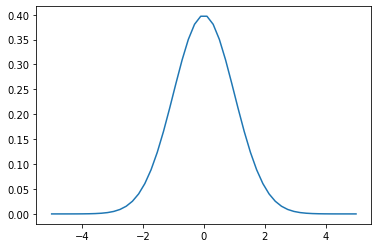

```python
plt.plot(x,normal_pdf)
plt.show()
```